# Ausentismo_Laboral

Ricardo Ortiz, Jaime Martinez & Jeisson Rodriguez

2025-04-12

# AUSENTISMO LABORAL

## Introducción

El ausentismo es definido como la ausencia de un empleado en su ambiente laboral con justificación o sin ella [1]. Cuando esto ocurre en una compañía se puede generar un aumento de costos (horas extra) en otros empleados llevando a sobrecarga o desmotivacion [2]. Las causas pueden ser múltiples, desde enfermedades, problemas económicos, razones personales, falta de interés, entre otras [3] En EE. UU. menos de la mitad de las compañías tiene un sistema de rastreo de ausentismo y solo un 16% implementan medidas para reducirlo [4], por esta razón este evento tiene un impacto significativo en el desarrollo financiero de las empresas teniendo un fuerte impacto en la estructura organizacional.

## Finalidad del estudio

El objetivo del análisis de este conjunto de datos es aplicar técnicas de series de tiempo para identificar el comportamiento del ausentismo a través de un periodo de tiempo; esto permitirá desarrrollar estrategias para maximizar la eficiencia operativa de la empresa al identificar los factores asociados al ausentismo laboral.

## Diseño del estudio

La base de datos a utilizar es *Absenteeism at work* es una base de acceso libre del UCI Machine Learning Repository cuyo dataset contiene información de julio de 2007 a julio de 2010 en una compañia en Brazil [5]. Los datos contienen 740 registros en 19 variables. Esta base de datos posee características que la hacen idónea para la investigación al poseer cobertura conceptual (la información corresponde a la finalidad del estudio), cobertura geográfica (Brazil), cobertura temporal (2007-2010) y amplitud porque en esta fuente de tipo secundario se obtendrá la información de las variables geográficas, demográficas y de otras variables relacionadas con el ausentismo.

Conjunto de datos disponible en: https://archive.ics.uci.edu/dataset/445/absenteeism+at+work

## Análisis de los datos

En el presente análisis se examina el comportamiento del ausentismo laboral a partir del conjunto de datos “Absenteeism at Work” disponible en el repositorio de la UCI Machine Learning. Para identificar patrones temporales y tendencias generales, se implementan técnicas de suavizamiento como la aproximación mediante promedios móviles. Además, se exploran los rezagos (lags) para evaluar la influencia de valores pasados en la dinámica actual del ausentismo, buscando detectar posibles relaciones de dependencia temporal. Finalmente, se realiza un análisis de estacionalidad para determinar si existen variaciones sistemáticas asociadas a ciclos recurrentes, como días de la semana, meses o estaciones del año, que afecten la frecuencia del ausentismo. Estas aproximaciones permiten construir una base sólida para entender mejor el fenómeno y orientar futuros modelos predictivos o estrategias de intervención en el contexto laboral.

A continuación se procede a cargar los datos de ausentismo laboral desde un archivo local, descargado directamente de: https://archive.ics.uci.edu/dataset/445/absenteeism+at+work. Se imprime el encabezado para ver el contenido del dataset.

```
##   ID Reason.for.absence Month.of.absence Day.of.the.week Seasons
## 1 11                 26                7               3       1
## 2 36                  0                7               3       1
## 3  3                 23                7               4       1
## 4  7                  7                7               5       1
## 5 11                 23                7               5       1
## 6  3                 23                7               6       1
##   Transportation.expense Distance.from.Residence.to.Work Service.time Age
## 1                    289                              36           13  33
## 2                    118                              13           18  50
## 3                    179                              51           18  38
## 4                    279                               5           14  39
## 5                    289                              36           13  33
## 6                    179                              51           18  38
##   Work.load.Average.day Hit.target Disciplinary.failure Education Son
```

[output cut: 20 more lines]

Al revisar los datos se identifica que la variable de interés que puede ser apropiada para hacer el análisis es el tiempo de ausentismo en horas, disponible en la variable *Absenteeism.time.in.hours*. La cuál es la variable objetivo del dataset según la descripción del mismo.

### Análisis Descriptivo

En primer lugar vemos algunas estadísticas descriptivas básicas para entender el comportamiento de la variable seleccionada:

#### Desviación estándar

```
##    Min. 1st Qu.  Median    Mean 3rd Qu.    Max.
##   0.000   2.000   3.000   6.924   8.000 120.000
```

```
## [1] 13.331
```

Acá vemos que el tiempo máximo de ausentismo es de 120 horas, con una mediana de 3 horas y un promedio de 7 horas aproximadamente. La desviación estándar arroja 13.3, esto indica que hay una variabilidad considerable en los datos, los datos están relativamente dispersos alrededor de la media.

Ahora vemos como se distribuyen los las hora de ausencia:

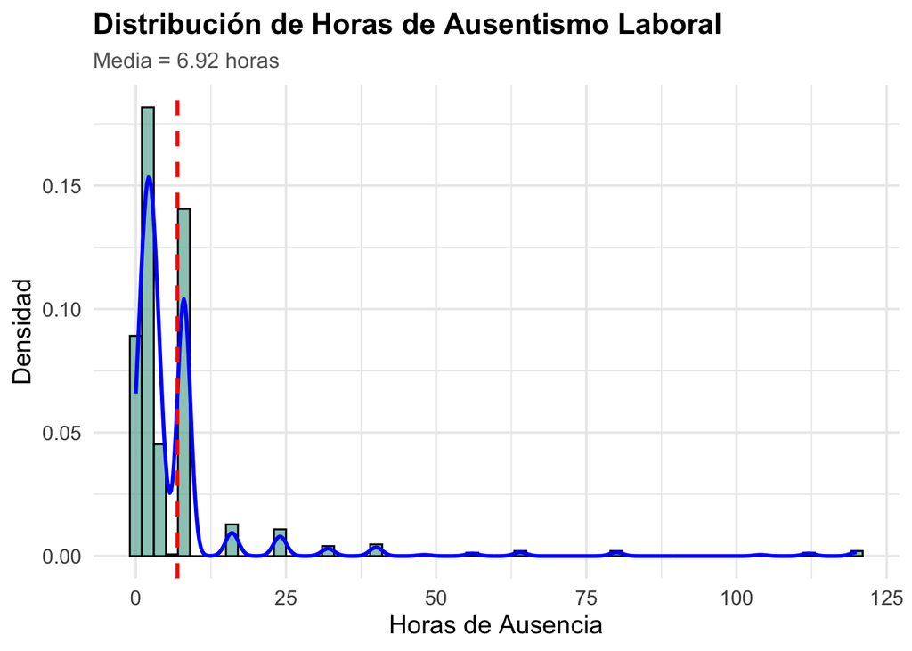

### Análisis de distribución de los datos

Del gráfico se puede observar que hay una asimetría positiva y que algunos valores de ausencia podrían incluso considerarse atípicos. Por esta razón se considera realizar un diagrama de cajas *(boxplot)*:

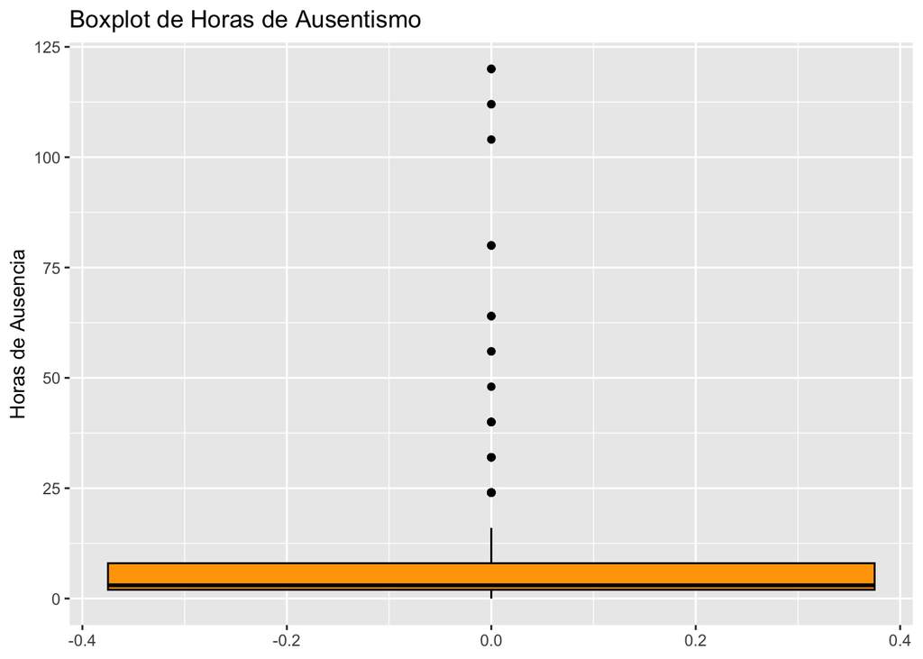

Acá vemos visualmente la asimetria y se identican con claridad algunos *outliers*, estando el 75% de los datos de ausencia por debajo de las 10 horas. Adicionalmente, se observa que hay una asimetría en la distribución según la posición de la media en la caja y en la separación de los “bigotes”.

Tambien, a partir de los plots anteriores se decidió realizar la revisión de los registros donde la ausencia es cero ( *no-ausencia*), esto es cerca del 6% de los datos, que corresponden a 44 registros.

### Presencia de datos faltantes

```
## [1] 44
```

```
## [1] 5.945946
```

Por otro lado, el dataset no incluye una fecha específica por lo que es necesario construirla a partir de variables tales como Month.of.absence y Day.of.the.weeek. Para ello, usamos el siguiente código.

```
## # A tibble: 6 × 26
##      ID Reason.for.absence Month.of.absence Day.of.the.week Seasons
##   <int>              <int>            <int>           <int>   <int>
## 1    34                 27                1               2       2
## 2    22                 27                1               2       2
## 3    34                 19                1               2       2
## 4     3                 28                1               6       2
## 5    28                 27                1               6       2
## 6     1                 13                1               3       2
## # ℹ 21 more variables: Transportation.expense <int>,
## #   Distance.from.Residence.to.Work <int>, Service.time <int>, Age <int>,
## #   Work.load.Average.day <dbl>, Hit.target <int>, Disciplinary.failure <int>,
## #   Education <int>, Son <int>, Social.drinker <int>, Social.smoker <int>,
## #   Pet <int>, Weight <int>, Height <int>, Body.mass.index <int>,
## #   Absenteeism.time.in.hours <int>, mes_formateado <chr>,
## #   primer_dia_mes <date>, dias_en_mes <int>, dia_aleatorio <int>, …
```

### Media Movil

El ausentismo laboral día a día puede tener mucha variabilidad, pues algunos días hay cero horas y otros días hay ausencias largas. La media móvil reduce las fluctuaciones diarias y muestra una tendencia más limpia. En este caso se generó un gráfico que muestra en rojo la variabilidad real y en azul la media móvil.

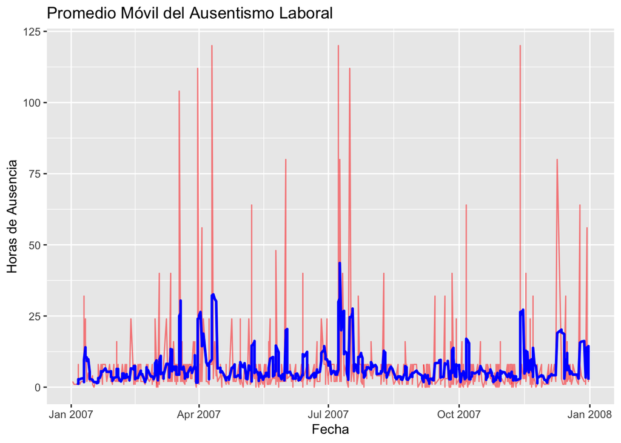

### Rezagos

El análisis de rezagos busca identificar si el ausentismo de hoy está relacionado con el ausentismo de días anteriores. Por ejemplo, interesa saber si un empleado que falta hoy tiene más probabilidad de faltar también mañana, o si, después de un día de alta ausencia, el ausentismo tiende a aumentar o disminuir en los días siguientes. Este tipo de relación temporal es fundamental para la construcción de modelos predictivos, como los modelos ARIMA o las regresiones que incorporan dependencias en el tiempo.

```
## [1] -0.05484861
```

```
## [1] 0.0468678
```

```
## [1] -0.02001964
```

Este tipo de gráfico muestra la relación entre el valor en *t* y su valor en *t-1*, esto es:

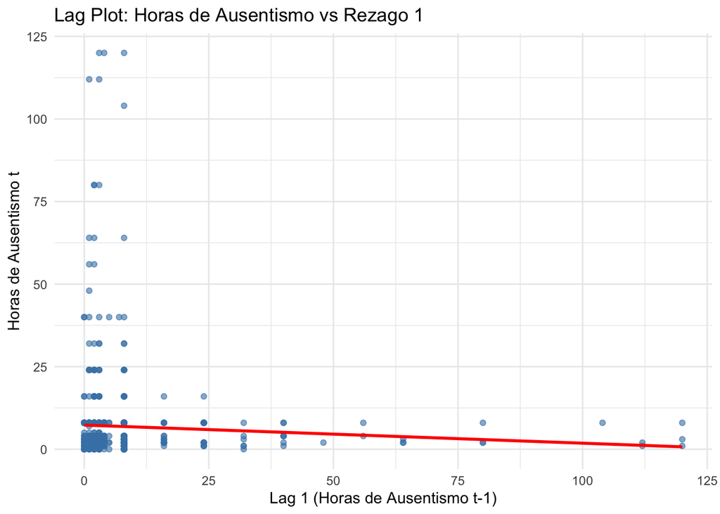

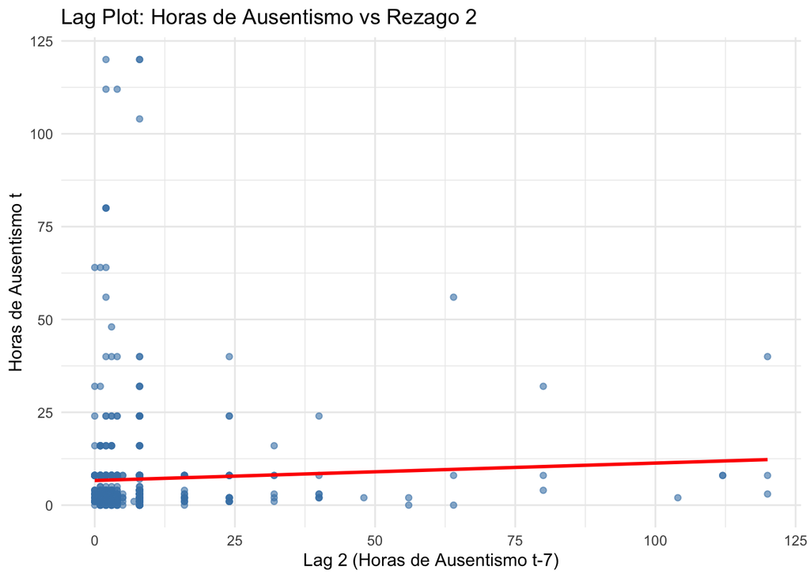

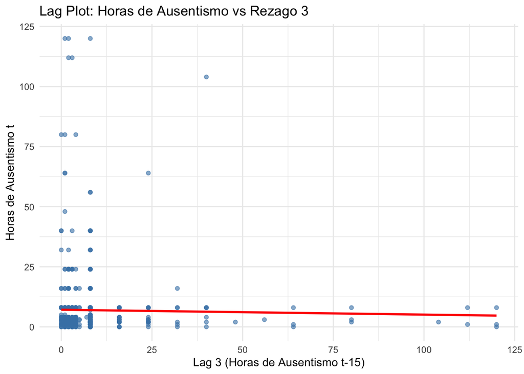

En estos gráficos podemos observar que los puntos son caóticos o dispersos en todos los rezagos, no hay dependencia fuerte en el rezago, es decir no hay mucha relación entre el valor actual y el pasado.

vamos a graficar la *Autocorrelation Function (ACF)*, esto mide cuánta correlación existe entre la serie y sus propios rezagos.

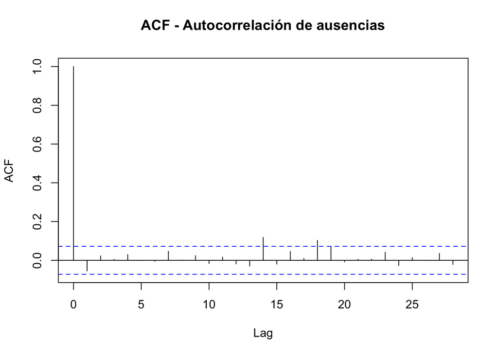

### Análísis de estacionalidad

La estacionalidad es un patrón repetitivo o cíclico que ocurre a intervalos regulares en una serie de tiempo, como cada semana, cada mes o cada año.

En este caso, queremos ver si hay momentos del año (o del mes) en los que el ausentismo tiende a aumentar o disminuir sistemáticamente.Como en el conjunto de datos tenemos el mes (simulado con fechas) y las horas de ausentismo, podemos ver si ciertos meses muestran mayores ausencias que otros.

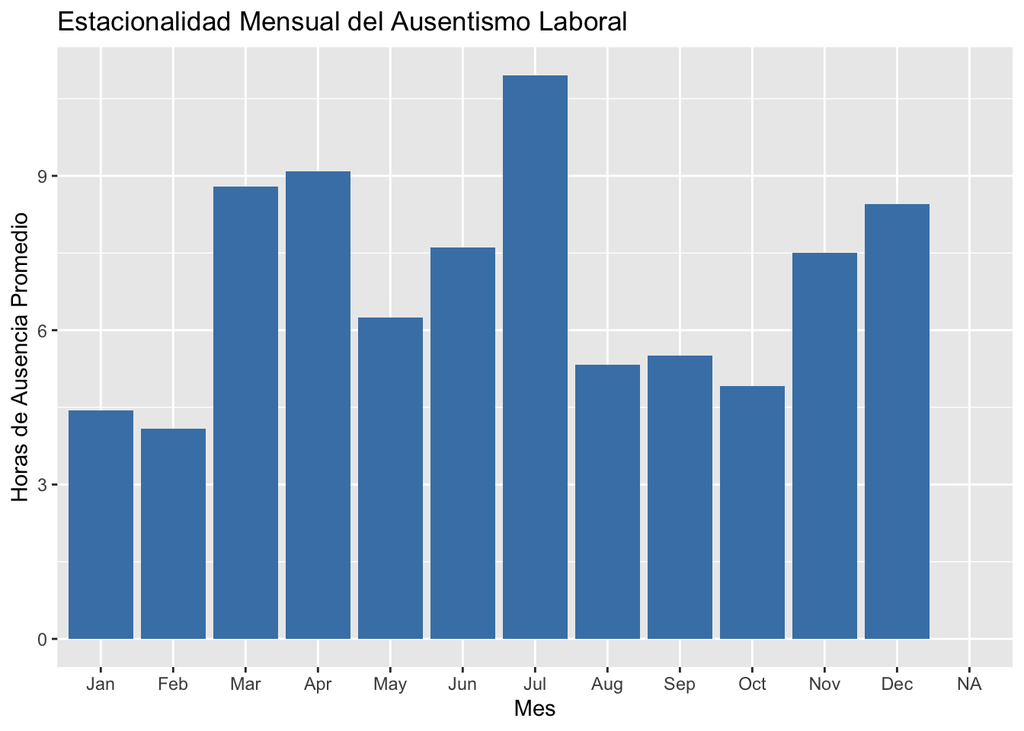

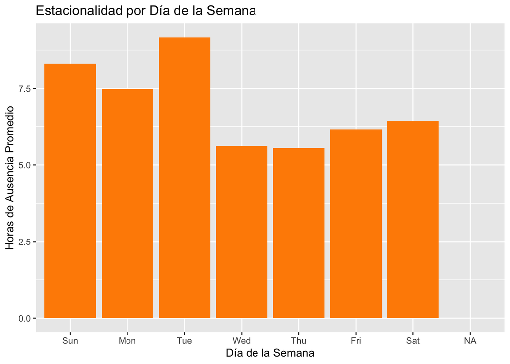

## Referencias bibliográficas

[1] Mowday RT, Porter LW, Steers RM (2013) Employee organization linkages: the psychology of commitment, absenteeism, and turnover. Academic press, New York

[2] De Stobbeleir KE, De Clippeleer I, Caniëls MC, Goedertier F, Deprez J, De Vos A, Buyens D (2018) The inside effects of a strong external employer brand: how external perceptions can influ ence organizational absenteeism rates. Int J Hum Resour Manag 29:2106–2136.

[3] Gonzalez BD, Grandner MA, Caminiti CB, Hui SA (2018) Cancer survivors in the workplace: sleep disturbance mediates the impact of cancer on healthcare expenditures and work absenteeism. Support Care Cancer 26:4049–4055.

[4] Kocakulah, M. C., Kelley, A. G., Mitchell, K. M., & Ruggieri, M. P. (2016). Absenteeism problems and costs: causes, effects and cures. The International Business & Economics Research Journal (Online), 15(3), 89.

[5] D. Dua and C. Graff, “Absenteeism at work Data Set,” UCI Machine Learning Repository, 2019. [Online]. Available: https://archive.ics.uci.edu/ml/datasets/Absenteeism+at+work